# Final Project:Analyzing Demographics, Admission Types, Insurance Variation, and Critical Outcomes in Niagara County Inpatient Discharges (2024)

Team 2: Simintaj Salehpour,Madeline Bumpus, Nazish Atta, Divya Mistry

December 03, 2025

# 1 Introduction

# 2 Data Description

## 2.1 Datasets used

This analysis uses data from the **New York State Department of Health (NYSDOH) Statewide Planning and Research Cooperative System (SPARCS)**, specifically the *Hospital Inpatient Discharges (SPARCS De-Identified)* dataset for **Niagara County, 2024**. The dataset includes detailed records of all hospital discharges statewide, with variables describing patient demographics, diagnoses, procedures, hospital facility characteristics, insurance/payment type, admission type, and clinical outcomes. Each row represents one patient discharge, allowing for analysis of trends in hospital length of stay, cost, and patient mix. The full dataset contains over **2 million records** across New York State; for this project, a subset of approximately **6,913 discharges from Niagara County** was used to maintain manageability and statistical power. This dataset is publicly available through the **NY Open Data Portal** and is widely used in healthcare policy, public health, and data science research.

```r
# Load CSV file
data <- read.csv("Hospital_Inpatient_Discharges_2024.csv")

#Clean column names to avoid backticks

names(data) <- make.names(names(data))

cat("Dataset dimensions: Rows:", nrow(data), "Columns:", ncol(data), "\n")
```

```
## Dataset dimensions: Rows: 6912 Columns: 33
```

```r
#glimpse(data)
```

## 2.2 Missing data

- Report missingness by variable: We check if there is a missing value or not. For each column check the missing value.

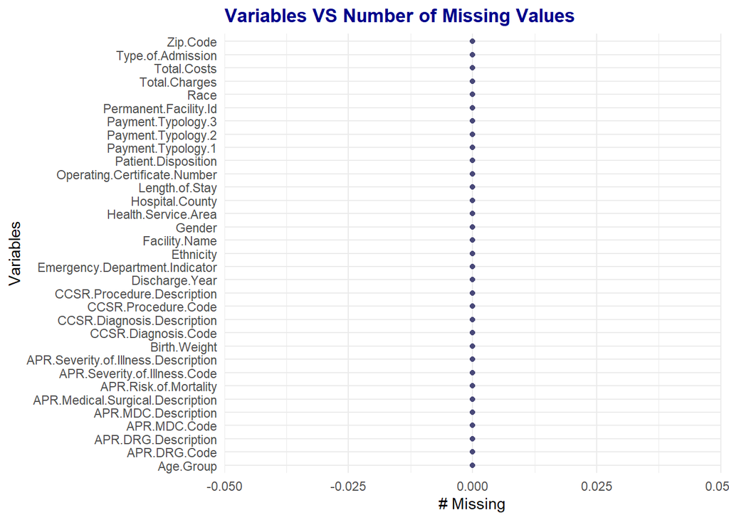

```r
# --- 1. Summary of missing values ---
missing_summary <- data %>% summarise(across(everything(), ~sum(is.na(.)))) %>%
  pivot_longer(everything(), names_to = "column(variable)", values_to = "n_missing") %>% arrange(desc(n_missing))

#missing_summary

# --- 2. Visualize missingness per column ---
gg_miss_var(data) + labs(title = "Variables VS Number of Missing Values") +
  theme( plot.title = element_text(face = "bold", color = "darkblue"))
```

```r
# --- 3. Check if there are any missing values ---
clean_data <- data
if(any(is.na(data))) {

  cat("Missing values detected!\n")
  total_missing <- sum(is.na(data))
  total_cells <- nrow(data) * ncol(data)

  # Remove rows if missing values are few (<5% of total data)
  if(total_missing / total_cells < 0.05) {
    clean_data <- na.omit(data)
    cat("Rows with missing values removed.\n")
  }
  else {
    # Impute numeric columns with median
    for(col in names(clean_data)) {
      if(is.numeric(clean_data[[col]])) {          # Check if the column is numeric
          clean_data[[col]][is.na(clean_data[[col]])] <- median(clean_data[[col]], na.rm = TRUE)
      }
    }
    cat("Missing values in numeric columns replaced with median.\n")
  }

} else {
  cat("No missing values detected. Dataset is clean.\n")
}
```

```
## No missing values detected. Dataset is clean.
```

## 2.3 Remove Duplicates

- Report Duplicates by row: Check to remove duplicates:

```r
dup_count <- sum(duplicated(clean_data))
cat("Number of duplicate rows:", dup_count, "\n")
```

```
## Number of duplicate rows: 1
```

```r
# Remove duplicates
clean_data <- clean_data %>% distinct()
```

# 3 SMART Questions

The team developed the following **SMART research questions** based on data availability, clinical reasoning, and literature review. These focus on measurable outcomes—length of stay and costs—to analyze healthcare disparities.

## 3.2 SMART Question 2

**What combination of patient demographics, admission type, and comorbidities predicts the lowest hospital charges for Medicaid vs. Private Insurance patients in 2024?**

```r
library(dplyr)
library(forcats)
library(ggplot2)
library(randomForest)

# Data cleaning
clean_data <- clean_data %>%
  mutate(
    Total.Charges = as.numeric(gsub("[^0-9\\.]", "", Total.Charges)),
    Length.of.Stay = as.numeric(as.character(Length.of.Stay))
  ) %>%
  filter(!is.na(Total.Charges), is.finite(Total.Charges), Total.Charges > 0)



# Filter Insurance types
medicaid_pattern <- "Medicaid|federal/state/local/va"
private_pattern  <- "Blue Cross/Blue Shield|Private Health Insurance|Miscellaneous/Other"

hospital_filtered <- clean_data %>%
  mutate(
    Insurance = case_when(
      if_any(starts_with("Payment.Typology"), ~ str_detect(., medicaid_pattern)) ~ "Medicaid",
      if_any(starts_with("Payment.Typology"), ~ str_detect(., private_pattern))  ~ "Private",
      TRUE ~ "Other"
    )
  ) %>%
  filter(Insurance %in% c("Medicaid", "Private"))


# Keep relevant columns
columns_to_keep <- c(
  "Age.Group", "Gender","Race", "Length.of.Stay","Type.of.Admission",
  "Emergency.Department.Indicator","APR.Medical.Surgical.Description",
  "APR.Severity.of.Illness.Description","APR.DRG.Code","CCSR.Diagnosis.Description",
  "Insurance","Total.Charges"
)
hospital_final <- hospital_filtered[, columns_to_keep]

# Convert low frequency levels to "Other" and handle NA
factors_to_fix <- c(
  "Age.Group","Gender","Race","Type.of.Admission",
  "Emergency.Department.Indicator","APR.Severity.of.Illness.Description","CCSR.Diagnosis.Description")

for(f in factors_to_fix){
  hospital_final[[f]] <- fct_lump_min(as.factor(hospital_final[[f]]), min = 20, other_level = "Other")
  hospital_final[[f]] <- fct_explicit_na(hospital_final[[f]], na_level = "Other")
}
cat("After labling Insurances as Medicaid and Private and remove other kinds like Medicare and self-payment \nStructure of final filtered dataset with demographics, admission type, and comorbidities variables to predicts the lowest hospital charges for Medicaid vs. Private Insurance: ")
```

```
## After labling Insurances as Medicaid and Private and remove other kinds like Medicare and self-payment
## Structure of final filtered dataset with demographics, admission type, and comorbidities variables to predicts the lowest hospital charges for Medicaid vs. Private Insurance:
```

```r
glimpse(hospital_final)
```

```
## Rows: 4,650
## Columns: 12
## $ Age.Group                           <fct> 50-69, 30-49, 50-69, 0-17, 30-49, …
## $ Gender                              <fct> M, F, F, F, F, F, M, F, F, F, F, F…
## $ Race                                <fct> White, Black/African American, Bla…
## $ Length.of.Stay                      <dbl> 3, 4, 1, 2, 6, 11, 2, 3, 5, 4, 2, …
## $ Type.of.Admission                   <fct> Emergency, Emergency, Emergency, N…
## $ Emergency.Department.Indicator      <fct> Y, Y, N, N, Y, Y, N, N, Y, Y, N, N…
## $ APR.Medical.Surgical.Description    <chr> "Medical", "Medical", "Surgical", …
## $ APR.Severity.of.Illness.Description <fct> Minor, Minor, Minor, Minor, Minor,…
## $ APR.DRG.Code                        <int> 243, 282, 320, 640, 751, 720, 174,…
## $ CCSR.Diagnosis.Description          <fct> "Other", "PANCREATIC DISORDERS (EX…
## $ Insurance                           <chr> "Medicaid", "Medicaid", "Medicaid"…
## $ Total.Charges                       <dbl> 10882.09, 12590.04, 11383.38, 4114…
```

```r
# Remove rows with any NA in predictors
predictors <- c(
  "Age.Group","Gender","Race","Type.of.Admission","Length.of.Stay",
  "Emergency.Department.Indicator","APR.Severity.of.Illness.Description","CCSR.Diagnosis.Description")
hospital_final <- hospital_final %>% filter(!if_any(all_of(predictors), is.na))


# Train/test split function with safe factor alignment
split_train_test <- function(df, train_ratio = 0.8) {
  set.seed(123)
  n <- nrow(df)
  train_idx <- sample(1:n, size = floor(train_ratio * n))
  train <- df[train_idx, ]
  test  <- df[-train_idx, ]

  for(f in names(train)[sapply(train, is.factor)]) {
    test[[f]] <- factor(test[[f]], levels = levels(train[[f]]))
    test[[f]] <- fct_explicit_na(test[[f]], na_level = "Other")
  }

  list(train = train, test = test)
}

# Split by Insurance
Medicaid_df <- hospital_final %>% filter(Insurance == "Medicaid")
Private_df  <- hospital_final %>% filter(Insurance == "Private")

medicaid_split <- split_train_test(Medicaid_df)
private_split  <- split_train_test(Private_df)

medicaid_split$train$logCharges <- log(medicaid_split$train$Total.Charges + 1)
medicaid_split$test$logCharges  <- log(medicaid_split$test$Total.Charges + 1)

private_split$train$logCharges <- log(private_split$train$Total.Charges + 1)
private_split$test$logCharges  <- log(private_split$test$Total.Charges + 1)
# Random Forest models

set.seed(123)
rf_medicaid <- randomForest(
  logCharges  ~ Age.Group + Gender + Race +
    Type.of.Admission + Length.of.Stay +
    Emergency.Department.Indicator +
    APR.Severity.of.Illness.Description +
    CCSR.Diagnosis.Description,
  data = medicaid_split$train,
  ntree = 500,
  mtry = 3,
  importance = TRUE
)
rf_medicaid
```

```
##
## Call:
##  randomForest(formula = logCharges ~ Age.Group + Gender + Race +      Type.of.Admission + Length.of.Stay + Emergency.Department.Indicator +      APR.Severity.of.Illness.Description + CCSR.Diagnosis.Description,      data = medicaid_split$train, ntree = 500, mtry = 3, importance = TRUE)
##                Type of random forest: regression
##                      Number of trees: 500
## No. of variables tried at each split: 3
##
##           Mean of squared residuals: 0.1065842
##                     % Var explained: 86.41
```

```r
# R² calculation
pred_log <- predict(rf_medicaid, medicaid_split$test)
real_log <- medicaid_split$test$logCharges
# R2 on log scale
# R2_log <- 1 - sum((pred_log - real_log)^2) / sum((real_log - mean(real_log))^2)
# cat("Medicaid:R2 (log scale):", R2_log, "\n")

# R2 on real scale
pred_real <- exp(pred_log) - 1
real_real <- medicaid_split$test$Total.Charges

R2_real <- 1 - sum((pred_real - real_real)^2) / sum((real_real - mean(real_real))^2)
cat("Medicaid: R2 (real scale):", R2_real, "\n")
```

```
## Medicaid: R2 (real scale): 0.799536
```

```r
rf_private <- randomForest(
  logCharges ~ Age.Group + Gender + Race +
    Type.of.Admission + Length.of.Stay +
    Emergency.Department.Indicator +
    APR.Severity.of.Illness.Description +
    CCSR.Diagnosis.Description,
  data = private_split$train,
  ntree = 500,
  mtry = 3,
  importance = TRUE
)
rf_private
```

```
##
## Call:
##  randomForest(formula = logCharges ~ Age.Group + Gender + Race +      Type.of.Admission + Length.of.Stay + Emergency.Department.Indicator +      APR.Severity.of.Illness.Description + CCSR.Diagnosis.Description,      data = private_split$train, ntree = 500, mtry = 3, importance = TRUE)
##                Type of random forest: regression
##                      Number of trees: 500
## No. of variables tried at each split: 3
##
##           Mean of squared residuals: 0.1605366
##                     % Var explained: 71.83
```

```r
# R² calculation
pred_log <- predict(rf_private, private_split$test)
real_log <- private_split$test$logCharges
# R2 on log scale
# R2_log <- 1 - sum((pred_log - real_log)^2) / sum((real_log - mean(real_log))^2)
# cat("Private:R2 (log scale):", R2_log, "\n")

# R2 on real scale
pred_real <- exp(pred_log) - 1
real_real <- private_split$test$Total.Charges

R2_real <- 1 - sum((pred_real - real_real)^2) / sum((real_real - mean(real_real))^2)
cat("Private: R2 (real scale):", R2_real, "\n")
```

```
## Private: R2 (real scale): 0.5393055
```

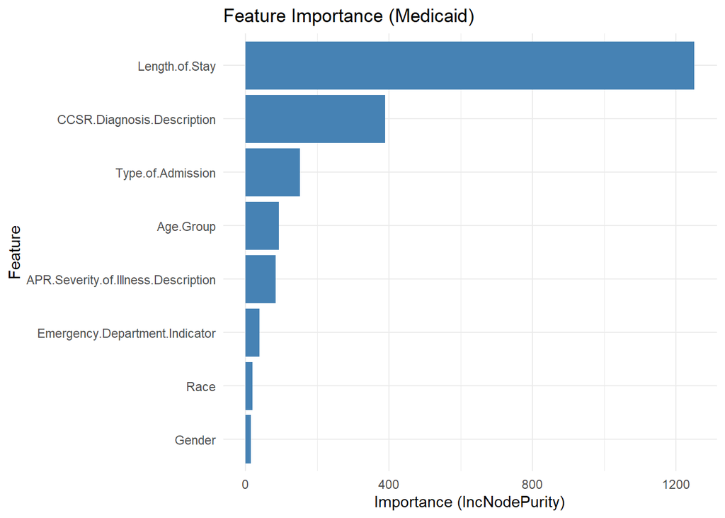

```r
top_features <- function(rf_model, n = 5){
  imp <- importance(rf_model)
  imp_df <- data.frame(
    Feature = rownames(imp),
    Importance = imp[, "IncNodePurity"]
  ) %>%
    arrange(desc(Importance))
  head(imp_df$Feature, n)
}

# Feature importance plots
plot_feature_importance <- function(rf_model, title = "Feature Importance") {
  imp <- importance(rf_model)
  imp_df <- data.frame(
    Feature = rownames(imp),
    Importance = imp[, "IncNodePurity"]
  ) %>% arrange(desc(Importance))

  ggplot(imp_df, aes(x = reorder(Feature, Importance), y = Importance)) +
    geom_col(fill = "steelblue") +
    coord_flip() +
    theme_minimal() +
    labs(title = title, x = "Feature", y = "Importance (IncNodePurity)")
}

# Medicaid
plot_feature_importance(rf_medicaid, title = "Feature Importance (Medicaid)")
```